# 1 度数分析

この章では，「

[figure not shown]

度数分析」ツールについて見ていきます。jamoviの基本構成では，ここには次の分析メニューが含まれています（図@ref(fig:frequencies-menu)）。

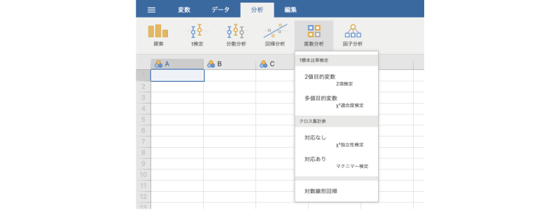

(#fig:frequencies-menu)度数分析のメニュー

- **1標本比率検定**
  - 2値目的変数［2項検定］
  - 多値目的変数［$\chi^{2}$適合度検定］
- **クロス集計表**
  - 対応なし［$\chi^{2}$独立性検定］
  - 対応あり［マクニマー検定］
- その他
  - 対数線形回帰

これらの分析メニューは，いずれも観測データの度数や比率について分析を行うものです。分析メニューは，1標本の検定と*クロス集計表*（*分割表*）の検定に分けられています。また，それらとは別に「対数線形回帰」のメニューも用意されています。「回帰」という名前がついていますが，これも度数に関する分析手法の1つです。

## 1.1 2値目的変数［2項検定］

とりうる値が「はい・いいえ」のように2種類しか存在しない*2値変数*について，その値の「はい・いいえ」の比率が基準の比率，または想定される比率と同じかどうかを確かめたい場合には，*2項検定*と呼ばれる検定方法が用いられます。

jamoviでは，従来型の一般的な方法による2項検定の他に，ベイズ統計の考え方を用いた検定を実施することも可能です。

### 1.1.1 考え方

次の例について考えてみましょう。同月齢の80人の幼児を対象としてある認知課題を実施しました。この課題は，この月齢の幼児では通過率70%といわれてきたのですが，今回の実施で課題を通過したのは80人中46人（通過率57.5%）でした（表@ref(tab:frequencies-table-pf)）。この課題の通過率は，本当に70%なのでしょうか。

(#tab:frequencies-table-pf)認知課題の通過率

|  | 人数 | % |
| --- | --- | --- |
| 通過 | 46 | 57.5% |
| 非通過 | 34 | 42.5% |
| 計 | 80 | 100% |

この例のように，測定値のとりうる値が「通過」または「非通過」の2とおりしかない場合，そのデータにおける「通過」または「非通過」の比率がどのように分布するかは，*2項分布*と呼ばれる確率分布を用いて確率的に求めることができます。

たとえば，この課題の通過率が実際に70%だったとしたとき，無作為に選んだ80人を対象とした調査で80人のうちの70%，つまり56人が課題に通過する確率は，2項分布を用いて計算すると0.0969…で，約9.7%の確率です[^1]。これは一見すると低いようにも感じられますが，全体（母集団）における比率が70%だからといって，そこから抽出した標本で毎回70%ちょうどになるわけではありません。それより1人少ない55人の場合や1人多い57人の場合を含めて考えてみると，80人中55人が通過する確率は0.093（9.3%），80人中57人なら0.095（9.5%）ですので，課題の通過者が80人中55〜57人になる場合であれば28%程度の確率で生じうるわけです。

先ほどは説明のために70%ちょうどの56人から前後1人の幅で考えましたが，実際の場面ではこれよりもっとばらつくことは普通にあるでしょう。極端な話，80人全員が課題に通過する場合や，その逆に全員が通過できない場合というのも，非常にまれなことには違いないですが，確率的には0ではありません。

そこで，母集団における通過率が70%である場合に，80人の標本で通過者が0人である場合から80人である場合までのすべての場合について確率を算出し，それを図示したのが図@ref(fig:frequencies-binomial-distribution)です。

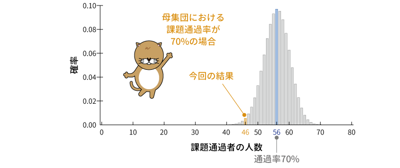

(#fig:frequencies-binomial-distribution)母集団における通過率が70%の場合の確率の分布

さすがに通過者が0人の場合や80人の場合というのは確率的には数値が小さすぎてグラフ上では0になってしまいますが，こうしてみると，母集団における通過率が70%の場合に，今回の結果のように通過者が46人になるというケースはそれなりにありうることだというのがわかります。とはいえ，今回の結果と同じか，あるいはそれよりも極端な結果になる確率というのはかなり小さく，確率的に見てまれな出来事であることには違いありません。

このように，2項検定では想定される比率をもつ母集団から標本データで得られた比率（およびそれより極端な比率）が得られる確率がどの程度であるかを算出します。そして，その確率が有意水準よりも小さい場合に，想定される母集団における比率と標本データの母集団の比率が有意に異なると判断します。

### 1.1.2 分析手順

分析に入る前に，先ほどの調査結果を次のようにスプレッドシートに入力しましょう（図@ref(fig:frequencies-data01)）。なお，人数は実際には連続変数ですが，分析の都合上，ここでは「名義型（

[figure not shown]

）」として設定してください。

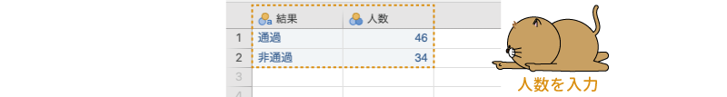

(#fig:frequencies-data01)サンプルデータ

- `結果` 課題の結果（通過，非通過）
- `人数` 通過・非通過の人数（通過：46人，非通過：34人）

それでは分析です。2項検定は，分析タブの「

[figure not shown]

度数分析」で「1標本比率検定」のところにある「2値目的変数［2項検定］」を選択して実行します（図@ref(fig:frequencies-binomial-menu)）。

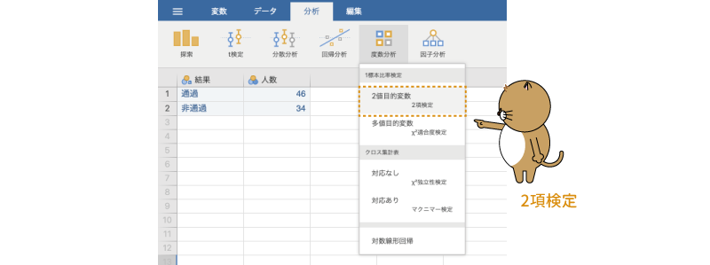

(#fig:frequencies-binomial-menu)2項検定の実行

すると，図@ref(fig:frequencies-binomial-setting)のような画面が表示されます。

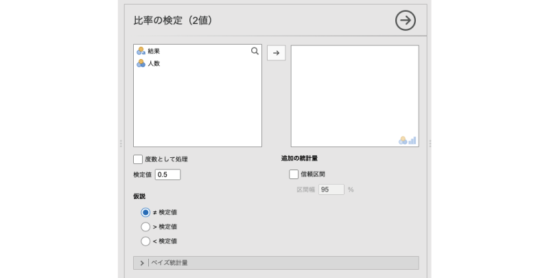

(#fig:frequencies-binomial-setting)2項検定の設定画面

- 度数として処理 度数が入力されている変数で分析を行う場合に使用します。
- 検定値 比較対象に使用する比率を指定します。
- **仮説** 検定の対立仮説に関する設定を行います。
  - ≠ 検定値 比率が検定値と異なるかどうかを検定します（両側検定）
  - > 検定値 比率が検定値より大きいかどうかを検定します（片側検定）
  - < 検定値 比率が検定値より小さいかどうかを検定します（片側検定）
- **追加の統計量** 追加の統計量に関する設定を行います。
  - 信頼区間 比率の信頼区間を算出します。

[figure not shown]

- | ベイズ統計量 ベイズ統計の手法を用いて検定する場合の設定項目です。

ここで，図@ref(fig:frequencies-binomial-set-var)のように設定を行います。まず，「人数」を選択して右側に移動してください。下のアイコンを見てもらえばわかるように，この欄には，名義型（

[figure not shown]

）か順序型（

[figure not shown]

）の変数でなければ移動することができません。先ほど「人数」を名義型に設定したのはこのためです。

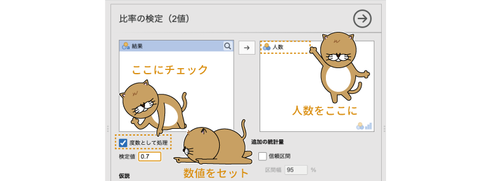

(#fig:frequencies-binomial-set-var)2項検定の分析設定

また，今回の分析データでは，課題通過者，非通過者の人数（度数）をデータとして入力してありますので，「度数として処理」にチェックを入れます。各対象者の「通過・非通過」の結果が1行ずつ入力されている場合には，このチェックは必要ありません。

それから，今回の仮説では，「この課題の通過率は70%（0.7）である」というのが正しいといえるかどうかを確かめたいので，「検定値」の値は「0.7」に設定します。

基本の設定はこれで終了ですが，それ以外の設定項目についてもここで見ておきましょう。

#### 仮説

「**仮説**」では，検定に使用する対立仮説の設定を行います。

- ≠ 検定値 比率が検定値と異なるかどうかを検定します（両側検定）
- > 検定値 比率が検定値より大きいかどうかを検定します（片側検定）
- < 検定値 比率が検定値より小さいかどうかを検定します（片側検定）

今回のデータでは，想定される母集団の比率どおりであれば80 × 0.7 = 56，課題通過者は46人なので，仮説は「< 検定値」にすべきではないかと思う人もいるかもしれません。ですが，統計的仮説検定の仮説はデータを見る前に設定するものなので，その場合，観測データで通過率が0.7より高いか低いかは見当がつきません。そこで，ここでの検定における対立仮説は「≠ 検定値」で両側検定とします。

#### 追加の統計量

また，「**追加の統計量**」の部分では，信頼区間を算出するかどうかの設定を行います。今回はこの設定は使用しませんが，信頼区間を算出したい場合は「信頼区間」の部分にチェックを入れてください。

### 1.1.3 分析結果

それでは結果を見てみましょう。分析結果は，図@ref(fig:frequencies-binomial-results)のような形で示されます。

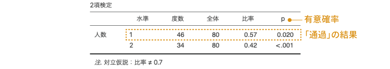

(#fig:frequencies-binomial-results)2項検定の分析結果

課題通過者の人数，非通過者の人数という集計結果をデータとして分析を行った場合，結果にはどちらが「通過」でどちらが「非通過」なのかは示されませんので，結果を見る際には注意してください。結果には，スプレッドシートに入力した順に「水準」欄に「1」，「2」として表示されます。分析に使用したデータでは1行目に通過者の人数，2行目に非通過者の人数を入力しましたので，この結果では水準が「1」の方が通過者です。

分析結果には，通過者の比率と非通過者の比率のそれぞれについての分析結果が示されますが，ここで見る必要があるのは通過者の比率（水準が1の行）の結果のみです。

この分析結果ではp = 0.020ですので，80人中46人が通過（通過率57.5%）という比率は，想定される通過率70%とは有意に異なるということがいえます。

### 1.1.4 ベイズ統計量

すでに分析結果は得られましたが，jamoviの2項検定では*ベイズ統計*の考え方を用いた検定も可能ですので，その方法についても見ておくことにしましょう。

まず，先ほどの分析結果をクリックして，2項検定の分析設定画面を開いてください。設定画面の

[figure not shown]

| ベイズ統計量を展開すると，次の設定項目が表示されます（図@ref(fig:frequencies-binomial-bayes-setting)）。

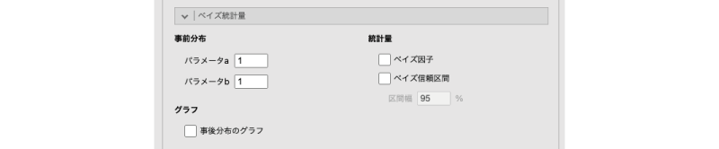

(#fig:frequencies-binomial-bayes-setting)ベイズ統計量の設定画面

- **事前分布**
  - パラメータa ベータ分布のaを設定します。
  - パラメータb ベータ分布のbを設定します。
- **グラフ**
  - 事後分布のグラフ 事後分布を図示します。
- **統計量**
  - ベイズ因子 ベイズ因子を算出します。
  - ベイズ信頼区間 ベイズ信頼区間（確信区間）を算出します。

#### 事前分布

ベイズ統計の詳細についてはベイズ統計の教科書を参照して欲しいと思いますが，ベイズ統計では，分析対象についての確率分布をあらかじめ設定し，その分布に対して観測データを与えて分析結果を得るという手順で分析を実施します。この際，分析対象についてあらかじめ設定する分布のことを*事前分布*と呼びます。

[figure not shown]

| ベイズ統計量の「**事前分布**」の部分は，この事前分布についての設定です。

jamoviの2項検定では，分析の事前分布として*ベータ分布*と呼ばれる確率分布を使用することができます。このベータ分布は，aとb（またはαとβ）という2つの*パラメータ*[^2]をもち，この2つの値の設定の仕方によって，じつにさまざまな形状の分布を表現することが可能です。そして，このベータ分布のパラメータaの値を「パラメータa」の入力欄に，パラメータbの値を「パラメータb」の入力欄に入力します。

しかし，パラメータの値を2つ入力してください，といわれても，どんな値を入力したらよいのか検討もつきませんね。すでに先行研究や予備調査などで分析対象のおおよその分布がわかっている場合には，事前分布がその形状になるようにaとbを設定することになりますが，そうでない場合，一般には特別な情報をもたない分布を事前分布として使用するという方法が用いられます。そしてその場合，もっとも一般に用いられる分布が*一様分布*と呼ばれる分布です。

この一様分布は，「サイコロの1から6の目が出る確率はすべて1/6で等しい」というように，どのような結果になる確率もすべて同率で等しいとする分布です。ベータ分布では，「a = b = 1」の場合にこの一様分布が得られます。jamoviの分析画面では，「パラメータa」も「パラメータb」も初期設定値は「1」になっていますが，それはこのような理由からです。ここでは「実際の課題通過率」に関して特別な仮説は持ち合わせていませんので，初期設定値どおり，aもbも「1」のままにしておきましょう。

#### 統計量

次に設定するのは「**統計量**」の部分です。ここの「ベイズ因子」の部分にチェックを入れない限り，ベイズ統計による分析結果は表示されません。ですので，ベイズ統計量が必要な場合には，「ベイズ因子」にチェックを入れておきましょう。

その下の「ベイズ信頼区間」は，*ベイズ信頼区間*あるいは*確信区間*などと呼ばれる，ベイズ統計の考え方にそった区間推定値を算出するための設定です。名前はよく似ていますが，従来型の推測統計における「信頼区間」とは別物ですので注意してください。ここでは，この設定はオフのままにしておきます。

ここまでの設定が終わったところで分析結果を見てみると，先ほどの結果の表の右端に，「ベイズ因子$_{10}$」という欄が追加されているはずです（図@ref(fig:frequencies-binomial-bayes-results)）。

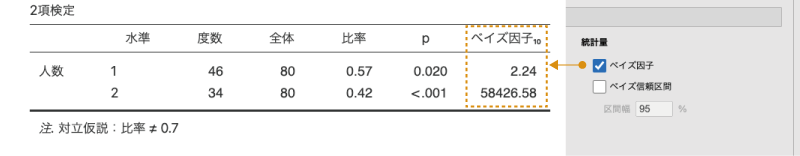

(#fig:frequencies-binomial-bayes-results)ベイズ因子の計算結果

ベイズ統計の場合も，分析結果の表で見る必要があるのは課題通過者についての行（**水準**が1の行）だけです。この行のベイズ因子の値は2.24で，これは対立仮説が正しい場合の確率が，帰無仮説が正しい場合の確率に比べて2.24倍大きいということを意味しています。

このベイズ因子の大きさの解釈については，複数の研究者によってさまざまな目安が提供されていますが，そのうちの1つ，[Kass & Raftery (1995)](https://www.tandfonline.com/doi/abs/10.1080/01621459.1995.10476572)[^3]では，表@ref(tab:frequencies-binomial-bayes-factor-interpretation)のように示されています。一般には，この値（ベイズ因子$_{10}$）が3を超える場合に，対立仮説を支持する証拠があるとみなされることが多いようです。

(#tab:frequencies-binomial-bayes-factor-interpretation)(#tab:frequencies-binomial-bayes-factor-interpretation)ベイズ因子の解釈の目安

[output not shown]

今回の分析結果ではベイズ因子は2.24でしたので，対立仮説を支持する証拠としては弱いものです。つまり，この分析結果からは，「課題の通過率は70%ではない」とはまではいえないことになります。

#### グラフ

最後に，「**グラフ**」の設定についても見ておきましょう。この「事後分布のグラフ」にチェックを入れると，課題通過と非通過のそれぞれについて，事前分布，尤度，事後分布を示したグラフが表示されます（図@ref(fig:frequencies-binomial-bayes-posterior)）。ここでは，課題通過の場合についてのプロットを見てみましょう。

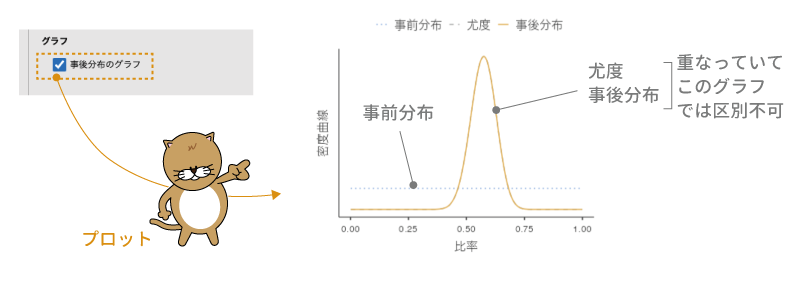

(#fig:frequencies-binomial-bayes-posterior)課題通過率についての事前・事後分布のグラフ

このグラフの横軸には通過率，縦軸には*確率密度*が示されています。確率密度というのは確率とはまた別物なのですが，ここでは大まかに確率の高さを表していると考えてもらって構いません。少し見づらいですが，グラフ中の青の点線が事前分布（一様分布）で，黄色の曲線が事後分布です。

このグラフを見ると，0.575周辺での確率がもっとも高く，そこから離れるにつれて確率が低くなっていくのがわかります。これは，80人中46人が課題通過というデータが得られた場合に，その母集団における通過率（母比率）は0.575周辺である可能性がもっとも高く，それより離れた値である可能性は低いということを示しています。

この事後分布のグラフでは，母集団における通過率が0.7である可能性というのは実際にはかなり低いことがわかります。ただし，先ほど分析結果でみたベイズ因子の値が示す限りでは，この程度であっても「この標本の母集団における通過率は70%ではない」というには証拠としてまだ弱いのです。

## 1.2 多値目的変数［χ²適合度検定］

変数のとりうる値が「はい・いいえ」や「あり・なし」のような2値でなく，3つ以上ある場合で，各変数値（カテゴリー）の比率について検定したい場合には，*カイ2乗適合度検定*と呼ばれる手法が用いられます。

### 1.2.1 考え方

次の例について考えてみましょう。

人の学習スタイルを大きく「視覚型（映像やイメージを利用した学習を好むスタイル）」，「聴覚型（音声を利用した学習を好むスタイル）」，「運動感覚型（運動や動作を用いた学習を好むスタイル）」の3とおりに分類したとすると，その一般的な比率は視覚型が65%，聴覚型が30%，運動感覚型が5%程度なのだそうです。

ここで，ある地域で小学生児童150人を無作為に選び，その児童の学習スタイルの判定を行ったところ，表@ref(tab:frequencies-chisq-table1)の結果が得られました。この地域の小学生における学習スタイルの比率は，一般的な比率とは異なっているのでしょうか。

(#tab:frequencies-chisq-table1)(#tab:frequencies-chisq-table1)学習スタイルの度数分布

[output not shown]

まず，この結果が想定される比率と異なるかどうかを見るためには，想定される比率の場合にどのような人数配分になるのかを知る必要があります。そこで，測定結果が想定される比率どおりであった場合に，それぞれのタイプの児童が何人ずつになると考えられるのかを考えてみましょう。一般的な比率が視覚型が65%，聴覚型が30%，運動感覚型が5%であるとした場合，150人の児童をこの比率に割り振ると表@ref(tab:frequencies-chisq-table2)のようになります。

(#tab:frequencies-chisq-table2)(#tab:frequencies-chisq-table2)学習スタイルの期待度数

[output not shown]

このような，想定される比率どおりに全体の人数を割り振った値は*期待度数*と呼ばれます。人数なのに「97.5人」と小数点を含む値になっているのは変だと思うかもしれませんが，これはあくまでも理論上の数値ですので，これで問題ありません。

そして，この状態と実際の観測データにおける人数（これを*観測度数*といいます）が異なるかどうかを知りたいわけですから，この期待度数と観測度数がどれだけずれているか，両者の差を求めてみます（表@ref(tab:frequencies-chisq-table3)）。

(#tab:frequencies-chisq-table3)(#tab:frequencies-chisq-table3)期待度数と観測度数のずれ

[output not shown]

こうしてみると，それぞれのスタイルで観測度数と期待度数にずれがあることがわかります。なお，観測度数も期待度数も合計人数は150人で同じですから，期待度数と観測度数のずれがあるということは，この2つの間で3つのスタイルの比率が異なっているということです。

そこで，このようにして求めた各スタイルにおける観測度数と期待度数のずれの大きさを1つの値にまとめ，その値を用いて観察された結果と想定される比率の間に差があるといえるかどうかを判断しようとするのがカイ2乗適合度検定の考え方です。

なお，それぞれのスタイルにおけるずれの大きさを1つの値にまとめる際，「ずれの大きさ」の値がマイナスというのは扱いづらいですので，ずれの値は2乗してマイナスが取り除かれます。また，97.5人いることが期待される視覚型と7.5人しかいないことが期待される運動感覚型とでは「1人のずれ」の大きさがもつ意味合いが同じとはいえません。そこで，これら2乗したずれの値をさらに期待度数の大きさで調整してから合計することによって，全体的なずれの大きさが求められます。このようにして求めた値は，$\chi^2$（カイ2乗）と呼ばれる値の分布に近似的に従うことがわかっています。

そこで，$\chi^2$分布を利用して，帰無仮説（母集団の比率と想定される比率の差は0である）のもとでその大きさのずれが生じる確率を計算します。そして，その確率が有意水準未満であった場合に，「母集団の比率と想定される比率は有意に異なる」と判断するのです。

### 1.2.2 分析手順

2項検定の場合と同様に，まずは分析用のデータを作成しましょう。先ほどの調査結果を，スプレッドシートに次のように入力してください（図@ref(fig:frequencies-data02)）。

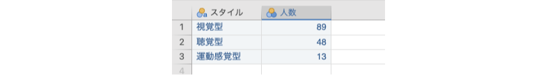

(#fig:frequencies-data02)サンプルデータ

- `スタイル` 学習スタイル（視覚型，聴覚型，運動感覚型）
- `人数` 各スタイルの人数（視覚型：89，聴覚型：48，運動感覚型：13）

データの入力が終わったら早速分析しましょう。カイ2乗適合度検定を実施するには，分析タブの「

[figure not shown]

度数分析」で「1標本比率検定」のところにある「多値目的変数［$\chi^2$適合度検定］」を選択します（図@ref(fig:frequencies-n-outcomes-goodness)）。

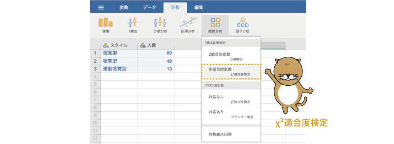

(#fig:frequencies-n-outcomes-goodness)適合度検定の実行

すると，図@ref(fig:frequencies-n-outcomes-goodness-setting)のような設定画面が表示されます。

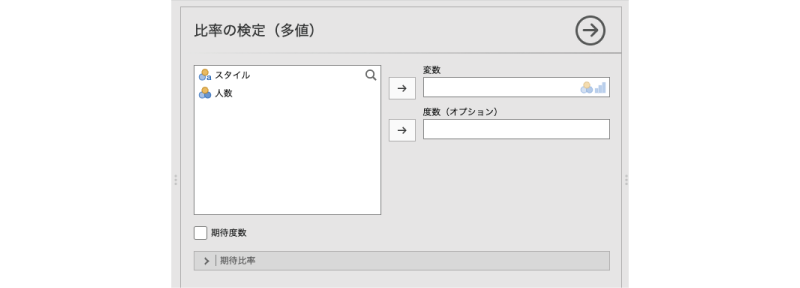

(#fig:frequencies-n-outcomes-goodness-setting)適合度検定の設定画面

- 変数 分析対象の変数を設定します。
- 度数（オプション） データが度数として入力されている場合に設定します。
- 期待度数 期待度数を算出します。

[figure not shown]

- | 期待比率 比較対象となる比率を設定します。

この画面で，「スタイル」を「変数」に移動します（図@ref(fig:frequencies-n-outcomes-goodness-set-var)）。

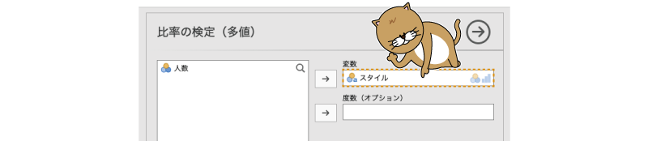

(#fig:frequencies-n-outcomes-goodness-set-var)分析対象の変数を設定

なお今回のデータは，2項検定のサンプルデータと同じく，すでに集計済みの度数が入力されています。「スタイル」には，視覚型，聴覚型，運動感覚型の値は1つずつしか含まれていませんので，このままではうまく分析できません。

そこで，各スタイルの度数が入った変数（「人数」）を「度数（オプション）」のところへ移動して，jamoviがそれぞれのスタイルの人数を認識できるようにします（図@ref(fig:frequencies-n-outcomes-goodness-set-count)）。この操作は，集計済みでないデータ（各個人の値が1行ずつ入力されているデータ）の場合には必要ありません。

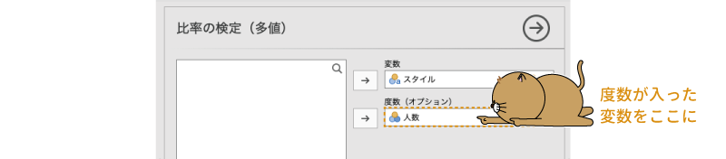

(#fig:frequencies-n-outcomes-goodness-set-count)各スタイルの度数を設定

これで分析の設定は終わりですといいたいところですが，このままではどのような比率とデータを比較するのかがわかりません。そのままでは適切な分析結果が得られませんので，比較対象となる比率を設定してやる必要があります。

### 1.2.3 期待比率

比較対象となる比率を設定するには，

[figure not shown]

| 期待比率を展開し，各変数値の「比率」のところに適切な数値を入力します（図@ref(fig:frequencies-n-outcomes-goodness-set-proportion)）。なお，日本語訳では真ん中の欄と一番右の欄がどちらも「比率」と表示されていますが，値を入力できるのは真ん中の欄のみです。真ん中の欄は正確には「比」で，ここに入力した数値をもとに計算された比率が一番右の欄に表示されます。

[figure not shown]

今回の例では，期待される割合は視覚型が65%，聴覚型が30%，運動感覚型が5%ですので，「視覚」の比に「65」，「聴覚」に「30」，「運動」に「5」を入力します。すると，その右の「比率」欄に，それぞれの型の比率が表示されます。入力の際には「水準」欄をよく確認し，入力する行を間違えないように注意しましょう。

なお，今回は使用しませんが，この設定を行ったあとに，

[figure not shown]

| 期待比率のすぐ上にある「期待度数」にチェックを入れると，指定した比率における期待度数を結果に表示させることもできます。

これで分析の設定は終了です。

### 1.2.4 分析結果

カイ2乗適合度検定の結果は次のような形で表示されます（図@ref(fig:frequencies-n-outcomes-goodness-results)）。

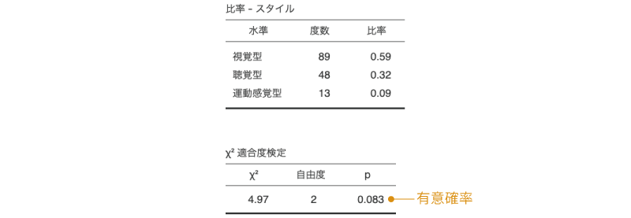

(#fig:frequencies-n-outcomes-goodness-results)適合度検定の分析結果

結果の1つ目の表は，観測データについての度数分布表です。今回は集計された度数をデータとして入力しましたが，1人1人の値が入力されているデータで分析を行う場合には，この度数分布表で各水準（変数値）の度数をよく確認しておきましょう。

その下の2つ目の表が適合度検定の結果です。適合度検定の結果の表には，検定統計量（$\chi^2$）と自由度，そして有意確率（p）の値が示されています。この表のpの値が有意水準を下回る場合に，このデータの母集団の比率が想定される比率と有意に異なると判断します。

今回の分析結果ではp = 0.083ですので，このデータ（小学生児童150人）の母集団における比率は，想定されている比率と有意に異なるとはいえません。

## 1.3 対応なし［χ²独立性検定］

ここからは**クロス集計表**（分割表）の分析についてみていきましょう。クロス集計表とは，行と列にそれぞれ異なる変数をとり，次のようにして複数の変数の値を組み合わせた形で集計をした表のことをいいます（表@ref(tab:frequencies-chisq-salad-table)）。

(#tab:frequencies-chisq-salad-table)(#tab:frequencies-chisq-salad-table)性別とサラダの好き嫌いについてのクロス集計表

[output not shown]

このようなクロス集計表を用いた分析では，表の列に位置する変数と行に位置する変数が互いに「独立」であるかどうかを確かめる*独立性検定*がよく用いられます。2つの変数が「互いに独立」であるとは，互いに無関係であるということです。

たとえば，先ほどの表@ref(tab:frequencies-chisq-salad-table)はサラダの好き嫌いと性別（男女）のクロス集計表ですが，この表を見ると，サラダが嫌いという回答の比率は，女性よりも男性の方が高くなっています。この場合，サラダを嫌いと答えたのは男性で100人中30人，女性では100人中10人というように，性別によってサラダの好き嫌いに違いが見られるので，サラダの好き嫌いと性別には関連があるということになります。

これに対し，次の表@ref(tab:frequencies-chisq-hamburg-table)では，男性と女性でハンバーグを好きだと答えた人と嫌いだと答えた人の比率は同じです。この場合には，ハンバーグの好き嫌いが性別によって異なるということはなく，ハンバーグの好き嫌いと性別は無関係（独立）であるといえます。

(#tab:frequencies-chisq-hamburg-table)(#tab:frequencies-chisq-hamburg-table)性別とハンバーグの好き嫌いについてのクロス集計表

[output not shown]

### 1.3.1 考え方

ここでは，次の例を用いて独立性検定の考え方を見ていきましょう。

成人男女各100人を対象に，「ショートケーキ」，「チーズケーキ」，「チョコレートケーキ」の中でどれが一番好きかを選んでもらいました。その結果をまとめたものがこのサンプルデータ（frequencies_data03.omv）です（図@ref(fig:frequencies-data03)）。

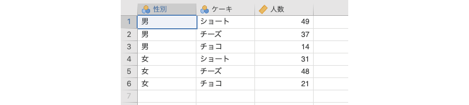

(#fig:frequencies-data03)サンプルデータ

- `性別` 性別（男，女）
- `ケーキ` ケーキの種類
  - ショートケーキ：`ショート`
  - チーズケーキ：`チーズ`
  - チョコレートケーキ：`チョコ`
- `人数` そのケーキを選んだ人数

この結果から，好きなケーキに男女で違いがあるといえるかどうか（独立でないといえるかどうか）を見たいとします。

まず，サンプルデータを選択したケーキと性別のクロス集計表の形にすると表@ref(tab:frequencies-cake-table1)のようになります。

(#tab:frequencies-cake-table1)(#tab:frequencies-cake-table1)性別とケーキの選択についてのクロス集計表

[output not shown]

さて，この結果から，ケーキの好み（どのケーキを選択したか）に男女による違いがあるかどうかをみるにはどうすればよいのでしょうか。統計的仮説検定の常として，そのような場合には，まず男女による違いが「ない」場合にどのようになるかを考えます。

ケーキの好みに男女による違いがない場合というのは，男性も女性も各ケーキの選択率が同じということです。もしそうだったとすると，男女ともに全体におけるケーキの選択率と同じ比率でそれぞれのケーキが選択されるはずです。つまり，表@ref(tab:frequencies-cake-table2)のような人数配分になるはずです。

(#tab:frequencies-cake-table2)(#tab:frequencies-cake-table2)性別とケーキの選択の期待度数

[output not shown]

そしてこれが，ケーキの選択と性別が独立（無関係）である場合の「期待度数」ということになります。

ここから先は，カイ2乗適合度検定の場合と考え方は同じです。この期待度数と，実際の観測データ（観測度数）の間で差を求め，その差の大きさを1つの値にまとめたうえで，そのようなずれの生じる確率がどの程度であるかを算出します。

この場合の帰無仮説は「ケーキの選択と性別は独立である」で，検定結果が有意であった場合には，「ケーキの選択と性別には関連がある（独立でない）」ということになります。

### 1.3.2 分析手順

独立性検定を実施するには，分析タブの「

[figure not shown]

度数分析」で「クロス集計表」のところにある「対応なし［$\chi^2$独立性検定］」を選択します（図@ref(fig:frequencies-chisq-menu)）。

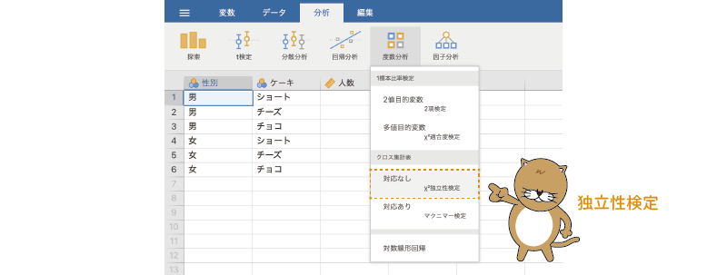

(#fig:frequencies-chisq-menu)独立性検定の実行

すると，図@ref(fig:frequencies-chisq-setting)のような画面が表示されます。

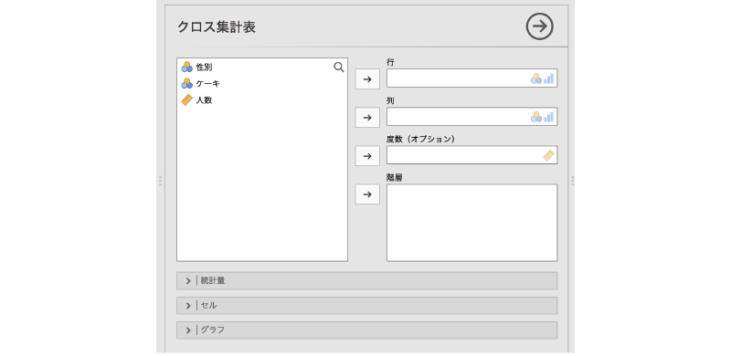

(#fig:frequencies-chisq-setting)独立性検定の設定画面

- 行 クロス集計表の行に配置する変数を指定します。
- 列 クロス集計表の列に配置する変数を指定します。
- 度数（オプション） 度数が含まれている変数を指定します（オプション）
- 階層 クロス集計表を分割する変数を指定します。

[figure not shown]

- | 統計量 統計量に関する設定を行います。

[figure not shown]

- | セル クロス集計表の各セルに関する設定を行います。

[figure not shown]

- | グラフ 結果をグラフに示します。

たくさんの設定項目があるのですが，基本的な分析はそれらを使用しなくても可能です。

分析では，クロス集計表の行と列に配置する変数を指定します。今回は，行に「性別」を，列に「ケーキ」を配置することにしましょう。

また，今回のデータもこれまでと同様に度数を集計済みのものですので，度数が入った変数（「人数」）を「度数（オプション）」のところに指定します。各個人の回答が1行ずつ入力されているデータの場合，この部分の設定は不要です。

設定後の画面は図@ref(fig:frequencies-chisq-setvar)のようになります。これで基本の分析設定は終了です。

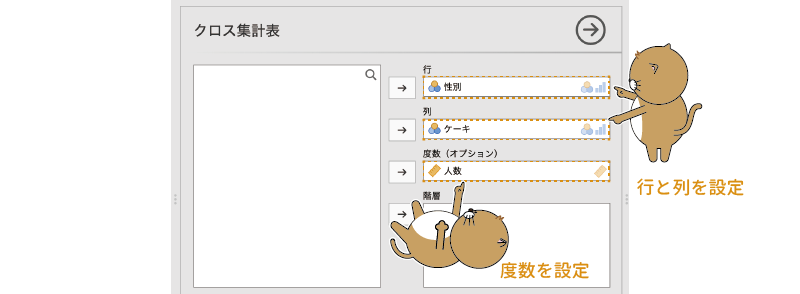

(#fig:frequencies-chisq-setvar)分析する変数を設定

### 1.3.3 分析結果

それでは結果を見てみましょう。分析結果は図@ref(fig:frequencies-chisq-results)のような形で得られます。

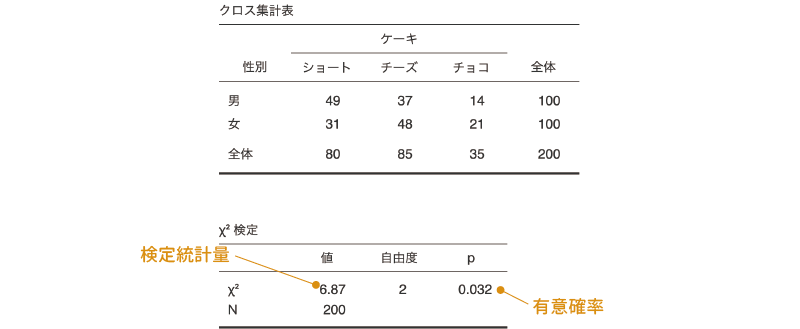

(#fig:frequencies-chisq-results)独立性検定の分析結果

1つ目の表は，観測データについての度数分布表です。行と列が正しく設定されているか確認しましょう。また，集計済みのデータではなく，1人1人の回答が入力されているデータで分析を行う場合には，この度数分布表でそれぞれの度数をよく確認しておきましょう。

その下の2つ目の表が独立性検定の結果です。独立性検定の結果の表には，適合度検定の場合と同じで検定統計量（$\chi^2$）と自由度，そして有意確率（p）の値が示されています。また，独立性検定の場合には，総度数（N）についても示されています。この表のpの値が有意水準を下回る場合に，このデータの母集団の比率が想定される比率と有意に異なると判断します。

今回の分析結果ではp = 0.032ですので，ケーキの選択と性別には関連がある（独立でない）ということになります。

### 1.3.4 層別分析

ここで，もう1つ別のデータをみてみましょう。次のサンプルデータ（frequencies_data04.omv）を開いてください。このデータは先ほどのデータとよく似ていますが，これは先ほどのデータに子供を対象に調査した結果を加えたものになっています（図@ref(fig:frequencies-data04)）。

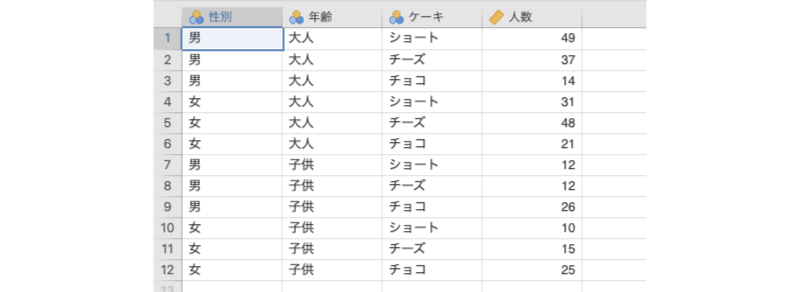

(#fig:frequencies-data04)サンプルデータ

- `性別` 性別（男，女）
- `年齢` 年齢（大人，子供）
- `ケーキ` ケーキの種類
  - ショートケーキ：`ショート`
  - チーズケーキ：`チーズ`
  - チョコレートケーキ：`チョコ`
- `人数` そのケーキを選んだ人数

先ほどと同様に，今回もケーキの選択と性別に関連があるか（独立でないか）について検討したいと思います。ただし，ここで気をつけなくてはならないのが，このデータには大人を対象とした調査結果と子供を対象とした調査結果が混在しているということです。大人と子供でケーキの好みに違いがなければ大人と子供のデータを一まとめにして分析してもよいでしょうが，大人と子供でケーキの好みに大きな違いがあるのであれば，正しい分析結果が得られない可能性が高くなります。

このようなデータの場合，ケーキの選択と性別の関連を適切に把握するために，分析対象のクロス集計表を大人と子供にグループ分けしたうえで分析するという方法がとられます。このようにしてクロス集計表を別のグループ変数で分割して分析する方法は，*層別分析*と呼ばれます。jamoviでは，この層別分析についても簡単に実行できるようになっています。

#### 分析手順

層別分析を実施するためには，「

[figure not shown]

度数分析」から「対応なし［$\chi^2$独立性検定］」を選択し，先ほどと同様に「行」に「性別」，「列」に「ケーキ」，そして「度数（オプション）」に「人数」を指定します。

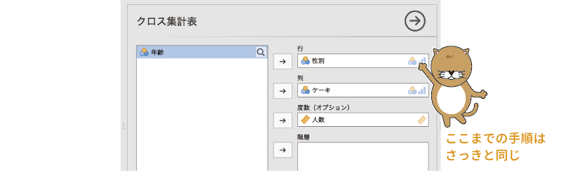

(#fig:frequencies-chisq-layer-set-var1)層別分析の設定（その1）

なお，「度数（オプション）」の設定は，各個人の回答が1行ずつ入力されているデータの場合には不要です。

そしてそのうえで，グループ変数である「年齢」を，設定画面の「階層」に設定します。

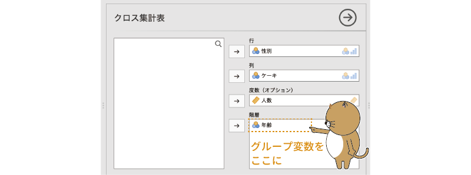

(#fig:frequencies-chisq-layer-set-var2)層別分析の設定（その2）

層別分析の設定はこれで終わりです。結果を見てみましょう。

#### 分析結果

分析の設定画面でグループ変数を「階層」に設定すると，分析結果は図@ref(fig:frequencies-chisq-layer-results)のような形になります。全体としての構成は大きく変わりませんが，度数分布表と独立性検定の結果には，データ全体での結果と，大人と子供というグループごとの結果（層別の分析結果）の両方が含まれています。

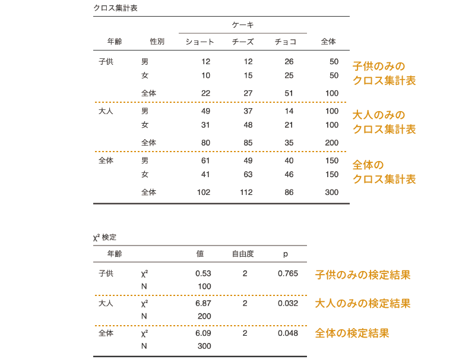

(#fig:frequencies-chisq-layer-results)層別分析の結果

この結果を見ると，大人ではケーキの選択と性別に有意な関連が見られますが，子供では有意な関連は見られません。つまり，大人か子供かによって，ケーキの選択の仕方と性別の関連は異なるということになります。

なお，全体での結果はp = 0.048で有意ですが，このデータでは大人は男女各100人であるのに対し，子供は男女各50人ですので，データ全体においては子供よりも大人の結果の影響が強く反映されているためと考えられます。したがって，この場合には全体の検定結果はあまり意味がありません。

### 1.3.5 統計量

ここからは分析設定の詳細について見ていきましょう。

[figure not shown]

| 統計量を展開すると，次の項目が表示されます（図@ref(fig:frequencies-chisq-statistics)）。

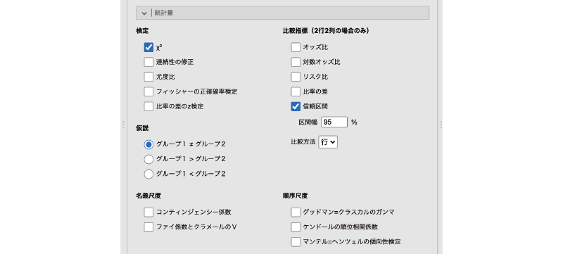

(#fig:frequencies-chisq-statistics)統計量の設定

- **検定** 検定統計量に関する設定を行います。
- **仮説** 対立仮説に関する設定を行います。
- **比較指標（2行2列の場合のみ）**
- **名義尺度** 名義尺度の関連についての指標を設定します。
- **順序尺度** 順序尺度の関連についての指標を設定します。

非常にたくさんの項目が含まれていますが，ただ項目が多いだけでなく，この中には2行2列のクロス集計表の場合のみ適用可能な項目や，層別分析の場合のみ適用可能な項目などがあり，少し複雑です。ここでは，これらを1つ1つ順番に見ていくことにしましょう。

#### 検定

「**検定**」の部分では，クロス集計表の検定に用いる検定手法についての設定を行うことができます（図@ref(fig:frequencies-chisq-statistics-tests)）。

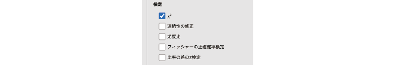

(#fig:frequencies-chisq-statistics-tests)検定の設定項目

- $\chi^2$ $\chi^2$統計量を算出します。
- 連続性の修正 $\chi^2$値に対して連続性の修正を行います。
- 尤度比 尤度比カイ2乗検定を行います。
- フィッシャーの正確確率検定 フィッシャーの正確確率検定を行います。
- 比率の差のz検定 比率の差に対してz検定を実施します。

一番最初の$\chi^2$については説明の必要はないと思いますので，2つ目以降の項目について簡単に見ていきます。

##### 連続性の修正

独立性の検定や適合度検定に用いられる検定統計量は$\chi^2$と呼ばれますが，実際には$\chi^2$の近似値であって，$\chi^2$の値そのものではありません。そのため，クロス集計表の特徴によっては，この近似の程度が低くなる場合があるのです。そしてそのような場合に，算出した検定統計量を$\chi^2$分布にできるだけ近づけるように，*イェーツの修正*，あるいは*イェーツの連続性の修正*と呼ばれる修正を加えることがあります。このイェーツの修正は，一般にはクロス集計表が2行2列である場合，標本サイズが小さく，クロス集計表に期待度数が5未満のセルが1つ以上ある場合に用いられます。

この「連続性の修正」の項目にチェックを入れると，イェーツの修正を行った後の$\chi^2$の値が算出されます（図@ref(fig:frequencies-chisq-continuity)）。

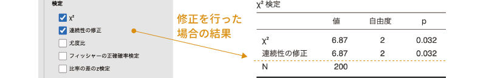

(#fig:frequencies-chisq-continuity)連続性の修正

この結果は大人のみのデータを使ったクロス集計表の分析結果に連続性の修正を適用したものですが，このデータでは連続性の修正をしてもしなくても同じ結果になっています。

なお，イェーツの修正については，値を「修正しすぎる」傾向があることが知られています。そのため，このような修正を行うべきかどうかについては専門家の間でも意見が分かれるところです。

##### 尤度比

「カイ2乗検定」というのは，検定統計量として$\chi^2$を用いるものの総称です。そして，独立性の検定として一般に用いられるカイ2乗検定は，*ピアソンのカイ2乗検定*とも呼ばれます。このように呼ばれるということは，それ以外のカイ2乗検定があるということです。

そして，その1つが*尤度比カイ2乗検定*です。ピアソンのカイ2乗検定では，$\chi^2$の値は期待度数と観測度数の差の2乗を元に算出されますが，尤度比カイ2乗検定では，$\chi^2$の値を期待度数と観測度数の比を用いて算出します。ほとんどの場合，この尤度比カイ2乗検定の結果はピアソンのカイ2乗検定の結果とよく似たものになります。また，結果の見方はピアソンのカイ2乗検定の場合と同じです（図@ref(fig:frequencies-chisq-lr)）。

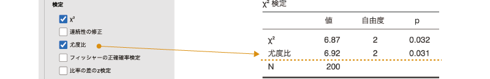

(#fig:frequencies-chisq-lr)尤度比

##### フィッシャーの正確確率検定

カイ2乗検定で算出される検定統計量は近似値であるため，標本サイズが小さいデータでは正確な結果が得られないといわれています。その場合，一般には*正確確率検定*と呼ばれる手法を用いて，今回の観測データと同じ結果になる確率がどの程度あるのかを直接的に計算して検定するという方法がとられます。その正確確率検定の中で，もっとも代表的なのが*フィッシャーの正確確率検定*，あるいは*フィッシャーの直接確率検定*と呼ばれる検定手法です。

この「フィッシャーの正確確率検定」にチェックを入れると，*フィッシャーの正確確率検定*による検定結果を表示することができます。なお，この方法では直接的に確率を計算するため，検定統計量は算出されません（図@ref(fig:frequencies-chisq-fisher)）。そのため，結果の表にはpの値だけが表示されます。このpの値が有意水準を下回る場合に，2つの変数の間に関連がある（独立でない）と判断します。

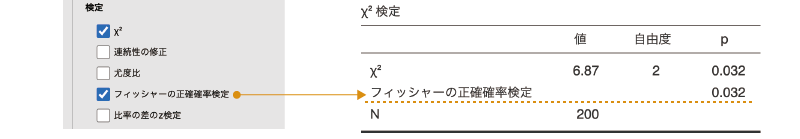

(#fig:frequencies-chisq-fisher)フィッシャーの正確確率検定

##### 比率の差のz検定

この項目は，クロス集計表が2行2列の場合にのみ適用可能なオプションです。

独立性検定の最初のところで用いたハンバーグへの好みと性別のクロス集計表のように，クロス集計表の行と列に関連がなく，互いに独立である場合には，男女でハンバーグの好き・嫌いの比率は同じになり，また，ハンバーグの好き・嫌いで男女比は同じになります。ということは，このようにして行ごと，列ごとで見た比率が同じでなければ，行に置かれた変数と列に置かれた変数は独立でないということになります。

「比率の差のz検定」の項目では，このような考え方から，各行および各列で度数の比率が同じといえるかどうかの検定を行います。度数の比率が等しければ，それは行と列が互いに独立であるということを意味し，そうでなければ行と列には関連があるということを意味するわけです。

たとえば，男女各100人にイヌとネコのどちらが好きかをたずねた結果をまとめたクロス集計表があるとしましょう（表@ref(tab:frequencies-chisq-cats-and-dogs)）。

(#tab:frequencies-chisq-cats-and-dogs)(#tab:frequencies-chisq-cats-and-dogs)性別とイヌ派・ネコ派についてのクロス集計表

[output not shown]

この表では，自分がイヌ派（ネコよりイヌが好き）と答えたのは男性では100人中70人（比率0.7），女性では100人中55人（比率0.55）ですので，男女の間でイヌ派の比率には0.15の差があります。この検定では，このようにして求めた比率の差を，全体におけるイヌ派の比率と男女それぞれの人数を用いてzに変換し，このzの値を用いて検定を行います。検定の結果が有意であった場合，2つの比率に差があるとみなします（図@ref(fig:frequencies-chisq-ztest)）。

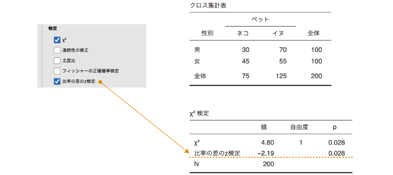

(#fig:frequencies-chisq-ztest)比率の差のz検定

イヌ派・ネコ派のデータについて比率の差の検定を行ったところ，p = 0.028で検定結果は有意となりました。この結果から，男女でイヌ派・ネコ派の比率に有意な差があるということになります。